# Peer assessment 1 submission - Reproducible Research

## Loading and preprocessing the data

First of all, we need to start with the data tune-up. This is the code for it:

*Code:*

```r
rawData <- read.csv("activity.csv")

complCas <- complete.cases(rawData)

procData <- rawData[complCas, ]
```

## What is mean total number of steps taken per day?

As per requested, the mean and median of the total number of steps taken per day are 10766.1 and 10765, respectively.

*Code:*

```r
uniqueCasesDate <- unique(procData$date)

dailySteps <- c()

meanDailySteps <- c()

for (i in 1:length(uniqueCasesDate)){

  dailySteps[i] <- sum(procData[which(procData$date == uniqueCasesDate[i]),"steps"])
  meanDailySteps[i] <- sum(procData[which(procData$date == uniqueCasesDate[i]),"steps"])/length(procData[which(procData$date == uniqueCasesDate[i]),"steps"])
}

complData <- data.frame(uniqueCasesDate, meanDailySteps)



meanSteps <- sum(dailySteps)/length(dailySteps)
medianSteps <- median(dailySteps)

print(paste("- The mean of the daily steps is ", meanSteps, sep = ""))
```

```
## [1] "- The mean of the daily steps is 10766.1886792453"
```

```r
print("")
```

```
## [1] ""
```

```r
print(paste("- The median of the daily steps is ", medianSteps, sep = ""))
```

```
## [1] "- The median of the daily steps is 10765"
```

Here is the histogram for the total number of steps taken each day:

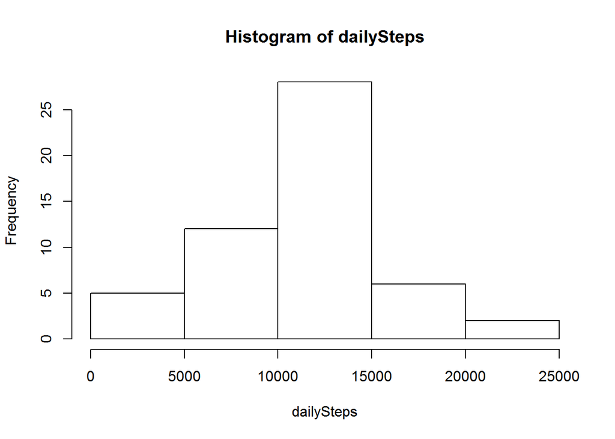

## What is the average daily activity pattern?

The interval with the most average steps is 835.

*Code:*

```r
uniqueCasesInter <- unique(procData$interval)

interSteps <- c()

for (i in 1:length(uniqueCasesInter)){

  interSteps[i] <- mean(procData[which(procData$interval == uniqueCasesInter[i]),"steps"])#/length(procData[which(procData$interval == uniqueCasesInter[i]),"steps"])
}




maxInterval <- uniqueCasesInter[which.max(interSteps)]

print(paste("- The interval with the most average steps is ", maxInterval, sep = ""))
```

```
## [1] "- The interval with the most average steps is 835"
```

This is the times series plot for the average number of steps taken, averaged across all days Vs. 5-minute interval:

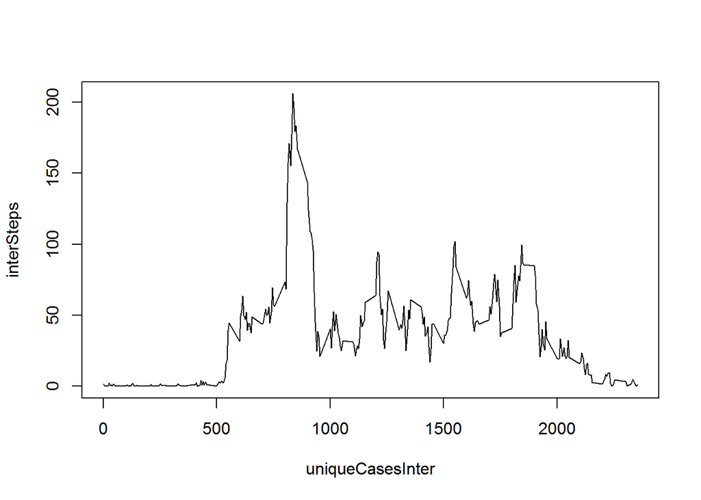

## Imputing missing values

*Code:*

```r
nComplCas <- sum(!complCas)

print(paste("- The number of rows with NA's is ", nComplCas, sep = ""))
```

```
## [1] "- The number of rows with NA's is 2304"
```

```r
corrRawData <- c()

lastAvg <- 0

for (i in 1:dim(rawData)[1]){

  if (!complCas[i]) {

    if(length(interSteps[rawData[i, "interval"]]) !=0){

      corrRawData[i] <- interSteps[rawData[i, "interval"]]

      lastAvg <- corrRawData[i]

    }else{

      corrRawData[i] <-  lastAvg
    }

  } else {

    corrRawData[i] <- rawData[i, "steps"]
  }



}

noNAdata <- data.frame(corrRawData, rawData$date, rawData$interval)
names(noNAdata) <- c("steps", "date", "interval")

dailySteps2 <- c()
meanDailySteps2 <- c()

for (i in 1:length(uniqueCasesDate)){

  dailySteps2[i] <- sum(noNAdata[which(noNAdata$date == uniqueCasesDate[i]),"steps"])
  meanDailySteps2[i] <- sum(noNAdata[which(noNAdata$date == uniqueCasesDate[i]),"steps"])/length(procData[which(procData$date == uniqueCasesDate[i]),"steps"])
}
```

Here is the plot for this part:

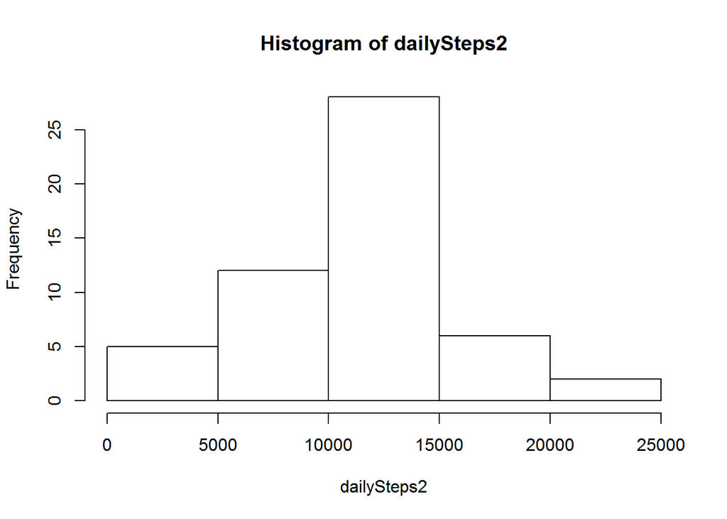

The values of the new data set do not differ significantly from the original dataset, as it can be seen in the aforementioned histogram.